# Overlapping_genes_seurat

Author

Pakorn Sagulkoo

After we carried out psedobulk gene expression analysis and GSEA for several RT scRNA-seq datasets, we will evaluate the consistency of gene expression results across those studies with calculated from Pseudobulk analysis using `FindMarkers()` in Seurat. We will explore overlapping genes among those studies.

## Import the relevant packages and set working path directory

```r
# Import the relavant packages
library(UpSetR)
library(dplyr)
library(tibble)
library(stringr)
library(ggplot2)
library(ggrepel)
```

```r
# Check root path
here::here()
```

```
[1] "/mnt/hp-storage/users/pakorns"
```

## Define paths

```r
# Define paths to load and save files
path_to_single_cell_analysis <- here::here("scRNAseq/systematic_review")
path_to_save_up_common_degs <- here::here("scRNAseq/systematic_review/6-consistency_assessment/overlapping_genes/seurat/1.upregulated_common_degs.txt")
path_to_save_down_common_degs <- here::here("scRNAseq/systematic_review/6-consistency_assessment/overlapping_genes/seurat/1.downregulated_common_degs.txt")
path_to_save_up_consist_rp <- here::here("scRNAseq/systematic_review/6-consistency_assessment/overlapping_genes/seurat/2.upregulated_rp.rds")
path_to_save_down_consist_rp <- here::here("scRNAseq/systematic_review/6-consistency_assessment/overlapping_genes/seurat/2.downregulated_rp.rds")
path_to_save_down_consist <-
path_to_save_up_consist_degs <- here::here("scRNAseq/systematic_review/6-consistency_assessment/overlapping_genes/seurat/3.upregulated_consist_degs.txt")
path_to_save_down_consist_degs <- here::here("scRNAseq/systematic_review/6-consistency_assessment/overlapping_genes/seurat/3.downregulated_consist_degs.txt")
```

## Load data and functions

```r
# Source functions
source(here::here("bin/utils.R"))
```

```r
# List file names of all studies
study.lst <- c("1-Penter_2021_GSE165087", "2-Nadeu_2022", "3-Hing_2022_GSE205704", "4-Parry_2023b", "5-Rigo_2024")
study.lst
```

```
[1] "1-Penter_2021_GSE165087" "2-Nadeu_2022"
[3] "3-Hing_2022_GSE205704"   "4-Parry_2023b"
[5] "5-Rigo_2024"
```

```r
# Create names for list later
names.lst <- sub(
  "^\\d+-([A-Za-z]+)_([0-9]{4}[A-Za-z]?).*$",  # capture name and year
  "\\1(\\2)",                         # output as Name(Year)
  study.lst
)
names.lst
```

```
[1] "Penter(2021)" "Nadeu(2022)"  "Hing(2022)"   "Parry(2023b)" "Rigo(2024)"
```

```r
# Extract only name of studies
study_names <- sub("^\\d+-([^_0-9]+).*", "\\1", study.lst)
study_names
```

```
[1] "Penter" "Nadeu"  "Hing"   "Parry"  "Rigo"
```

## Pseudobulk gene expression using `FindMarkers()` in Seurat

```r
# Load expression results in each study and collect in a list
path_to_download <- str_c(path_to_single_cell_analysis, "/", study.lst, "/expression_data/", study_names, "_dea.rds")
dea.lst <- purrr::pmap(
  list(path_to_download),
  function(path){
    expr.mat <- readRDS(path)
    return(expr.mat)
  }
)
names(dea.lst) <- names.lst
```

### Upregulated genes

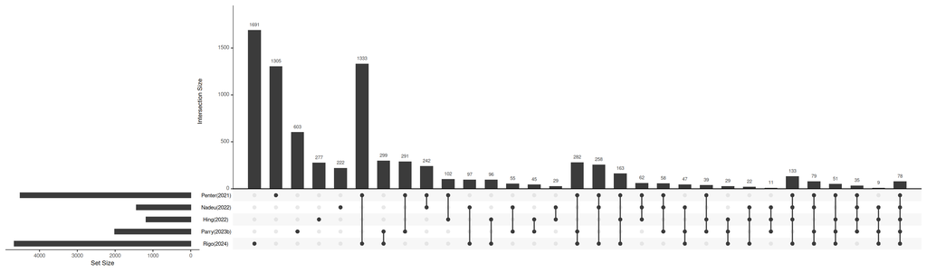

```r
# Extract adjusted significant upregulated genes
sig_upreg_gene.lst <- purrr::pmap(
  list(dea.lst),
  function(dea){
    selected_gene <- dea[dea$avg_log2FC > 0.25 & dea$p_val_adj < 0.05, "gene"]
    return(selected_gene)
  }
)

# Reorder the list first
sig_upreg_gene.lst <- sig_upreg_gene.lst %>%
  purrr::discard(~ length(.x) == 0) %>%   # drop empty ones
  rev()                                   # reverse order

# Convert to UpSetR input
upset_data <- fromList(sig_upreg_gene.lst)

# Plot UpSetR
upset(
  upset_data,
  sets = colnames(upset_data),      # ensures only these sets
  keep.order = TRUE,
  nintersects = NA
)
```

```r
# Collect upregulated DEGs
five_common_up_degs <- Reduce(intersect, sig_upreg_gene.lst)
five_common_up_degs
```

```
 [1] "TXN"      "COX5A"    "JPT1"     "HMGA1"    "NDUFB5"   "MARCKS"
 [7] "TKT"      "VDAC1"    "CKS2"     "GRHPR"    "CCDC167"  "MRPL14"
[13] "GAS5"     "PSMB8"    "PPA1"     "MTHFD2"   "NDUFA13"  "SELENOH"
[19] "CLTA"     "BRK1"     "PRDX5"    "LDHA"     "ATP5PD"   "BIK"
[25] "ALKBH7"   "MRPS33"   "UFC1"     "NPM1"     "NOB1"     "NME2"
[31] "ST13"     "TIMM13"   "TXNDC5"   "MRPL40"   "GGCT"     "HSPA8"
[37] "HSPD1"    "ADSL"     "LSM2"     "CSTB"     "EIF3G"    "PGD"
[43] "DNPH1"    "IMPDH2"   "PDCD5"    "CACYBP"   "MVD"      "ISOC2"
[49] "AHCY"     "MRPS25"   "MIF"      "ATP5PO"   "STOML2"   "EIF3K"
[55] "CENPM"    "DMAC1"    "PAFAH1B3" "MRPL4"    "MTHFD1"   "PAICS"
[61] "COMT"     "STMN1"    "C11orf1"  "JAGN1"    "CBR1"     "NME1"
[67] "WNT3"     "NPM3"     "GATD3B"   "NDUFAF3"  "CLPP"     "RPP25L"
[73] "MTFP1"    "AFMID"    "BCL2A1"   "ACY1"     "UBE2T"    "AGMAT"
```

### Downregulated genes

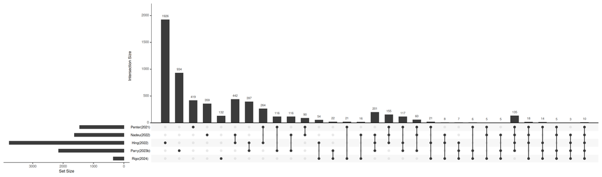

```r
# Extract adjusted significant downregulated genes
sig_downreg_gene.lst <- purrr::pmap(
  list(dea.lst),
  function(dea){
    selected_gene <- dea[dea$avg_log2FC < (-0.25) & dea$p_val_adj < 0.05, "gene"]
    return(selected_gene)
  }
)

# Reorder the list first
sig_downreg_gene.lst <- sig_downreg_gene.lst %>%
  purrr::discard(~ length(.x) == 0) %>%   # drop empty ones
  rev()                                   # reverse order

# Convert to UpSetR input
upset_data <- fromList(sig_downreg_gene.lst)

# Plot UpSetR
upset(
  upset_data,
  sets = colnames(upset_data),      # ensures only these sets
  keep.order = TRUE,
  nintersects = NA
)
```

```r
# Collect downregulated DEGs
five_common_down_degs <- Reduce(intersect, sig_downreg_gene.lst)
five_common_down_degs
```

```
 [1] "RPL21" "PNRC1" "SF1"   "VAMP2" "CCNI"  "MDM4"  "SRRM2" "SRSF7" "OTUD1"
[10] "IGKC"
```

```r
# Save the common DEG results
write.table(
  five_common_up_degs,
  file = path_to_save_up_common_degs,
  sep = "\t",
  quote = FALSE,
  row.names = FALSE,
  col.names = FALSE
)

write.table(
  five_common_down_degs,
  file = path_to_save_down_common_degs,
  sep = "\t",
  quote = FALSE,
  row.names = FALSE,
  col.names = FALSE
)
```

## Evaluate gene-ranked consistency

From the previous step, we got 78 and 10 for common up- and downregulated DEGs from all studies. However, we are not sure if these DEGs are common from ranking by chance. We will evaluate thier rank based on log2FC by using RankProd package. The package evaluates the statistics of gene rank across several gene expression studies by modelling ranked genes as probability distribution for the sum of outcomes by rolling *K* dices with *N* faces, similar to measuring *N* genes in expression analysis across *K* replicates or studies.

```r
# Import the relavant packages
library(RankProd)
```

```r
# Join dea tables from all studies
common_dea.df <- dea.lst[[1]] %>%
  mutate(log2FC_1 = avg_log2FC) %>%
  select(gene, log2FC_1)

# Loop over the rest
for (i in 2:length(dea.lst)) {

  # Rename dynamically with :=
  df_i <- dea.lst[[i]] %>%
    mutate(!!paste0("log2FC_", i) := avg_log2FC) %>%
    select(gene, !!paste0("log2FC_", i))

  # Join onto the growing table
  common_dea.df <- full_join(common_dea.df, df_i, by = "gene")
}

# Result: one data frame with gene and log2FC_x columns
head(common_dea.df)
```

```
      gene  log2FC_1      log2FC_2   log2FC_3   log2FC_4    log2FC_5
1 IGLV1-51  4.755051            NA         NA  9.9635246          NA
2   VPREB3  2.728487 -1.6135395654  2.9405267 -0.9199730 -0.43600770
3 IGHV3-23  3.467319  2.6624317384         NA  9.0334266          NA
4   RPS4Y1  1.640501  0.0002805457         NA -1.6390358 -0.03341585
5 HLA-DRB5 -4.646862 -0.9500024288  0.1026364 -0.9915919  1.46042149
6   TYROBP  3.553752 -0.9430261610 -0.3059755  1.8668365  2.76919821
```

```r
# Perform Rank Product
expr_mat <- as.matrix(common_dea.df[ , -1])   # all columns except gene
rownames(expr_mat) <- common_dea.df$gene
cl=rep(1, ncol(expr_mat))
RP.out <- RankProducts(expr_mat, cl, na.rm=FALSE, logged=TRUE, rand=123)
```

```
Rank Product analysis for paired case


 done
```

```r
# Summarise results of significant consistent genes
RP_sig_results <- topGene(RP.out, cutoff=0.05, method="pfp", logged=TRUE, logbase=2, gene.names=rownames(expr_mat))
```

```
Table1: Genes called significant under class1 < class2

Table2: Genes called significant under class1 > class2
```

We will explore the RP results for both upregulated and downregulated genes.

```r
# Upregulated genes table
RP_up_genes.df <- RP_sig_results[["Table2"]]
DT::datatable(RP_up_genes.df, options = list(scrollX = TRUE))
```

|  | gene.index | RP/Rsum | FC:(class1/class2) | pfp | P.value |
| --- | --- | --- | --- | --- | --- |
| AC245123.1 | 902 | 1 | 162.6 | 3.193e-17 | 2.4e-21 |
| MYL2 | 13196 | 1 | 118.6 | 1.597e-17 | 2.4e-21 |
| KLHDC8A | 8741 | 2 | 341.3 | 1.131e-14 | 2.55e-18 |
| TYMS | 8754 | 3 | 296.9 | 2.307e-13 | 6.938e-17 |
| RNF175 | 13132 | 3 | 3080 | 1.846e-13 | 6.938e-17 |
| SERHL2 | 908 | 4 | 70.62 | 1.329e-12 | 5.996e-16 |
| IGLC6 | 11140 | 4.472 | 900.7 | 2.551e-12 | 1.342e-15 |
| HYKK | 8751 | 5 | 193.4 | 4.926e-12 | 2.963e-15 |
| IGLV3-25 | 11134 | 5 | 216.1 | 4.379e-12 | 2.963e-15 |
| IGHEP1 | 13137 | 5 | 1885 | 3.941e-12 | 2.963e-15 |

[output cut: 1168 more lines]

```r
# Downregulated genes table
RP_down_genes.df <- RP_sig_results[["Table1"]]
DT::datatable(RP_down_genes.df, options = list(scrollX = TRUE))
```

|  | gene.index | RP/Rsum | FC:(class1/class2) | pfp | P.value |
| --- | --- | --- | --- | --- | --- |
| AC011446.2 | 11141 | 1 | 0.07451 | 3.193e-17 | 2.4e-21 |
| RPRML | 13191 | 1 | 0.001811 | 1.597e-17 | 2.4e-21 |
| LAMP5 | 13131 | 2 | 0.001181 | 1.131e-14 | 2.55e-18 |
| DPEP1 | 13195 | 2 | 0.005901 | 8.48e-15 | 2.55e-18 |
| IGHV1-2 | 1006 | 3 | 0.0001185 | 1.846e-13 | 6.938e-17 |
| AC007389.3 | 11144 | 4 | 0.09386 | 1.329e-12 | 5.996e-16 |
| LINC00472 | 13198 | 4 | 0.01348 | 1.14e-12 | 5.996e-16 |
| IGHV3-74 | 1361 | 5 | 0.0002131 | 4.926e-12 | 2.963e-15 |
| PVR | 13130 | 5 | 0.02478 | 4.379e-12 | 2.963e-15 |
| IGLV2-14 | 76 | 6 | 0.0002985 | 1.399e-11 | 1.051e-14 |

[output cut: 664 more lines]

```r
# Save the RP results
saveRDS(RP_up_genes.df, path_to_save_up_consist_rp)
saveRDS(RP_down_genes.df, path_to_save_down_consist_rp)
```

## Find overlapping between common DEGs and significant consistent ranked genes

We have identified common DEGs and significantly consistent ranked genes. We will next identify the common DEGs that are rank-consistent in order to evaluate their expression-rank robustness across all studies.

```r
# Collect consistent gene names from both up- and downregulated genes
consist_up_genes <- rownames(RP_sig_results[["Table2"]])
consist_down_genes <- rownames(RP_sig_results[["Table1"]])
```

After that, we will identify overlappping genes in both DEGs and consistent ranked genes.

```r
# Finding overlapping upregulated genes between DEGs and consistent ranking
consist_rank_up_degs <- intersect(five_common_up_degs, consist_up_genes)
consist_rank_up_degs
```

```
 [1] "TXN"     "JPT1"    "HMGA1"   "NDUFB5"  "MARCKS"  "TKT"     "VDAC1"
 [8] "CKS2"    "GRHPR"   "MRPL14"  "PPA1"    "MTHFD2"  "LDHA"    "BIK"
[15] "MRPS33"  "NOB1"    "TIMM13"  "GGCT"    "HSPD1"   "ADSL"    "PGD"
[22] "IMPDH2"  "ISOC2"   "AHCY"    "CENPM"   "MTHFD1"  "PAICS"   "COMT"
[29] "C11orf1" "CBR1"    "NME1"    "WNT3"    "NPM3"    "GATD3B"  "RPP25L"
[36] "MTFP1"   "AFMID"   "BCL2A1"  "ACY1"    "UBE2T"   "AGMAT"
```

```r
# Finding overlapping downregulated genes between DEGs and consistent ranking
consist_rank_down_degs <- intersect(five_common_down_degs, consist_down_genes)
consist_rank_down_degs
```

```
[1] "PNRC1" "OTUD1" "IGKC"
```

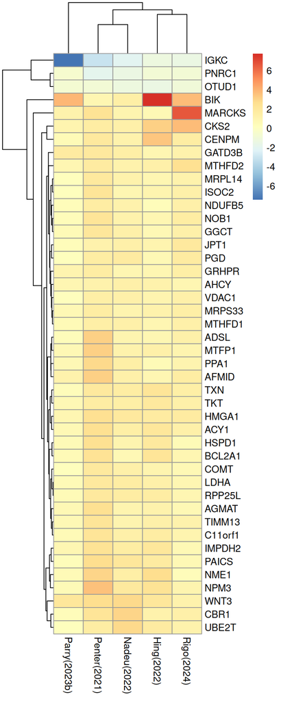

```r
# Visualise the heatmap
library(pheatmap)

# Extract expression matrix with rank-consistent DEGs
consiste_sig_genes <- c(consist_rank_up_degs, consist_rank_down_degs)
consiste_sig_expr_mat <- expr_mat[consiste_sig_genes, ]
colnames(consiste_sig_expr_mat) <- names.lst

# Plot the heatmap
pheatmap(consiste_sig_expr_mat, scale="none")
```

We will save these genes for further study and discussion.

```r
# Save the results
write.table(
  consist_rank_up_degs,
  file = path_to_save_up_consist_degs,
  sep = "\t",
  quote = FALSE,
  row.names = FALSE,
  col.names = FALSE
)

write.table(
  consist_rank_down_degs,
  file = path_to_save_down_consist_degs,
  sep = "\t",
  quote = FALSE,
  row.names = FALSE,
  col.names = FALSE
)
```